# Классификация с помощью дерева решений

Заходякин Г.В.

19 апреля 2017 г

# Подготовка

## Загрузка пакетов

```r
library(tidyverse) # Трансформация и визуализация данных
library(scales) # Процентный формат для осей ggplot
library(rpart) # Деревья в R: recursive partitioning
library(C50) # Деревья в R: C5.0
library(party) # Деревья в R: conditional inference
library(rpart.plot) # Визуализация деревьев
library(partykit) # Визуализация деревьев
#library(rattle)
library(mlr) # Фреймворк для машинного обучения, здесь используется для подсчета показателей ошибки
```

## Подготовка данных

```r
d <- readRDS("turnover.RDS")

# Обучающая и тестовая выборка
set.seed(1234)
train_indices <-  sample(1:nrow(d), size = 2000)
d_train <- d[train_indices, ]
d_test <- d[-train_indices, ]

# Что получилось
glimpse(d_train)
```

```
## Observations: 2,000
## Variables: 10
## $ satisfaction_level    <dbl> 9.9, 7.2, 7.0, 4.2, 5.9, 8.2, 7.2, 4.4, ...
## $ last_evaluation       <dbl> 6.8, 5.3, 5.3, 4.9, 7.9, 9.7, 8.8, 5.4, ...
## $ number_project        <dbl> 5, 3, 2, 2, 3, 5, 3, 2, 5, 5, 2, 5, 6, 3...
## $ average_monthly_hours <dbl> 264, 179, 274, 152, 217, 263, 224, 139, ...
## $ time_in_company       <dbl> 10, 3, 4, 3, 4, 5, 3, 3, 3, 4, 3, 2, 4, ...
## $ work_accident         <fct> yes, no, no, no, no, no, no, no, no, no,...
## $ left                  <fct> stayed, stayed, left, left, stayed, left...
## $ promotion_last_5years <fct> no, no, no, no, no, no, no, no, no, no, ...
## $ department            <fct> support, support, sales, support, produc...
## $ salary                <fct> medium, low, low, low, medium, medium, l...
```

# Моделирование с использованием алгоритма CART

## Два количественных предиктора (rpart)

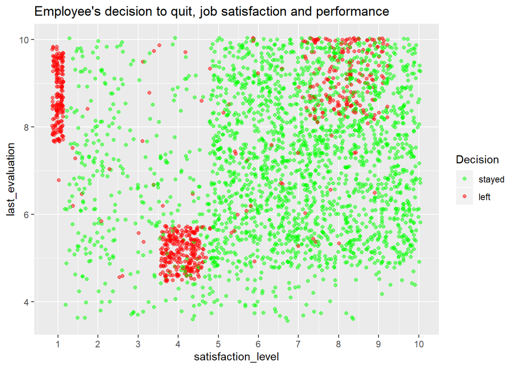

```r
cmap <- c("stayed" = "green", "left" = "red")

ggplot(d, aes(x = satisfaction_level, y = last_evaluation)) +
  geom_jitter(aes(colour = left), alpha = 0.5) +
  labs(title = "Employee's decision to quit, job satisfaction and performance", colour = "Decision") +
  scale_x_continuous(breaks = 1:10) +
  scale_colour_manual(values = cmap)
```

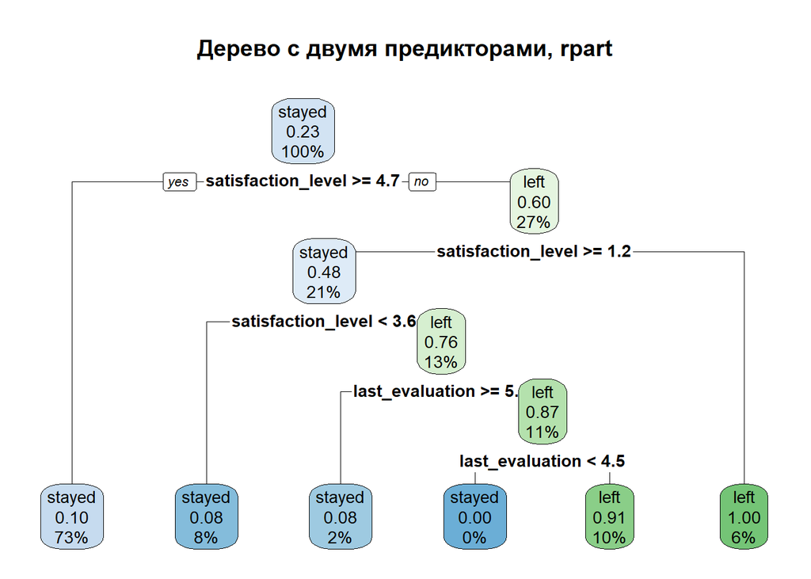

```r
m_rpart2 <- rpart(left ~ satisfaction_level + last_evaluation,
                 data = d_train)
rpart.plot(m_rpart2, tweak = 1.5,
           main = "Дерево с двумя предикторами, rpart")
```

```r
print(m_rpart2)
```

```
## n= 2000
##
## node), split, n, loss, yval, (yprob)
##       * denotes terminal node
##
##  1) root 2000 470 stayed (0.766 0.234)
##    2) satisfaction_level>=4.6 1454 140 stayed (0.904 0.096) *
##    3) satisfaction_level< 4.6 546 220 left (0.399 0.601)
##      6) satisfaction_level>=1.1 422 200 stayed (0.517 0.483)
##       12) satisfaction_level< 3.5 170  13 stayed (0.924 0.076) *
##       13) satisfaction_level>=3.5 252  61 left (0.242 0.758)
##         26) last_evaluation>=5.8 36   3 stayed (0.917 0.083) *
##         27) last_evaluation< 5.8 216  28 left (0.130 0.870)
##           54) last_evaluation< 4.4 10   0 stayed (1.000 0.000) *
##           55) last_evaluation>=4.4 206  18 left (0.087 0.913) *
##      7) satisfaction_level< 1.1 124   0 left (0.000 1.000) *
```

### Визуализация разделяющей поверхности

Т.к. в модели только два количественных предиктора, можно нарисовать разделяющую классы поверхность.

```r
# Сетка значений от 0 до 10 с шагом 0.1
gr <- expand.grid(satisfaction_level = seq(0, 10, by = 0.1),
             last_evaluation = seq(3, 10, by = 0.1))
```

```r
# Добавляем прогноз класса и вероятность ухода
boundary_rpart2 <- gr %>%
  mutate(prob = predict(m_rpart2, newdata = gr, type = "prob")[,'left'],
         class = predict(m_rpart2, newdata = gr, type = "class"))
```

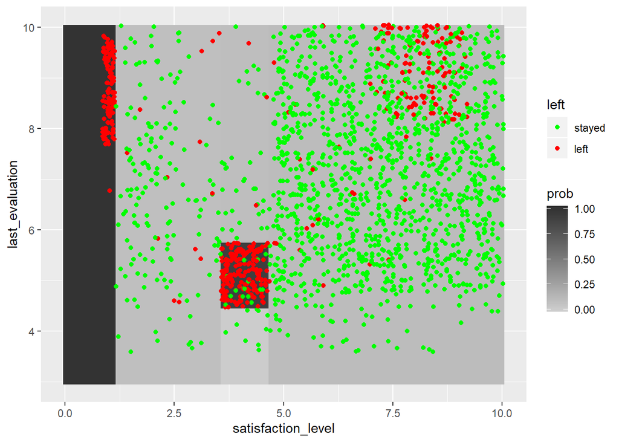

```r
ggplot(boundary_rpart2, aes(satisfaction_level, last_evaluation)) +
  geom_raster(aes(fill = prob)) +
  geom_jitter(aes(x = satisfaction_level,
                  y = last_evaluation,
                  colour = left),
              data = d_train) +
  scale_colour_manual(values = cmap) +
  scale_fill_gradient(low = "grey80", high = "grey20")
```

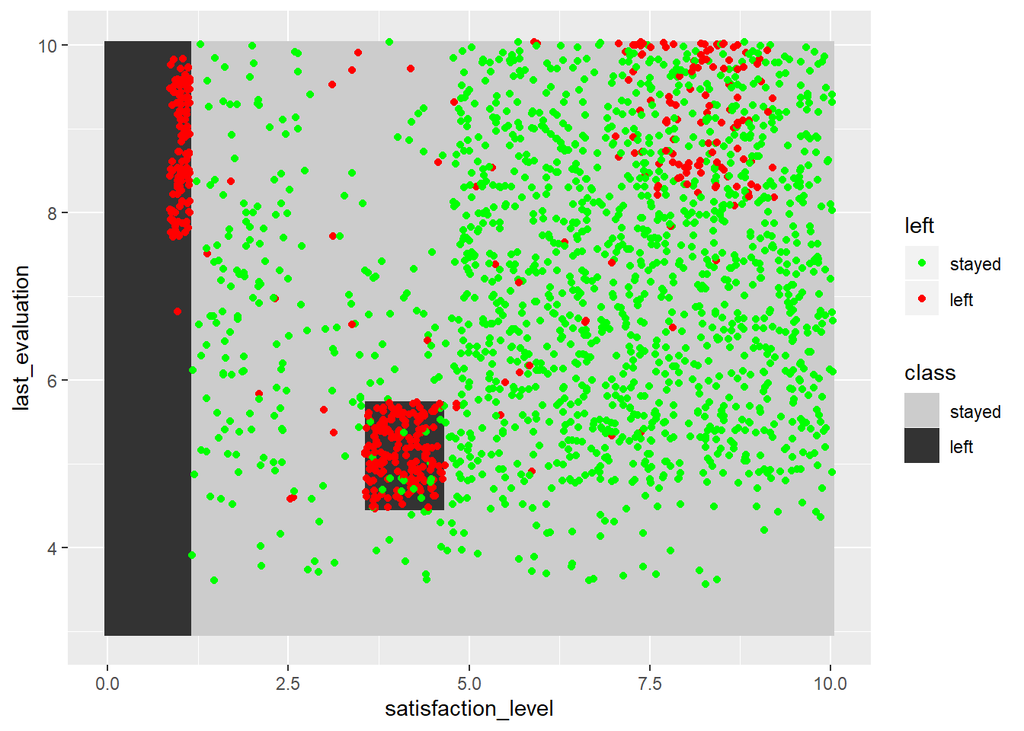

```r
ggplot(boundary_rpart2, aes(satisfaction_level, last_evaluation)) +
  geom_raster(aes(fill = class)) +
  geom_jitter(aes(x = satisfaction_level,
                  y = last_evaluation,
                  colour = left),
              data = d_train) +
  scale_fill_grey(start = 0.8, end = 0.2) +
  scale_colour_manual(values = cmap)
```

### Сравнение критериев разбиения

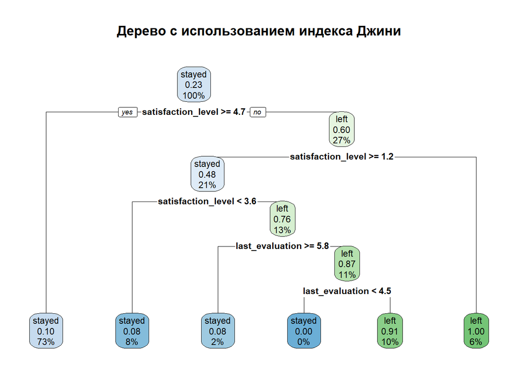

```r
m_rpart2_gini <- rpart(left ~ satisfaction_level + last_evaluation ,
                         data = d_train,
                         parms = list(split = "gini"))
rpart.plot(m_rpart2_gini, tweak = 1.25,
           main = "Дерево с использованием индекса Джини")
```

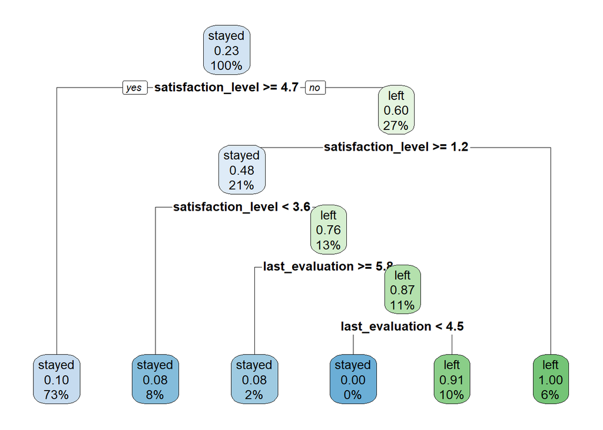

```r
m_rpart2_information <- rpart(left ~ satisfaction_level + last_evaluation,
                         data = d_train,
                         parms = list(split = "information"))
rpart.plot(m_rpart2_information, tweak = 1.25)
```

### Оценка точности модели

**Матрица классификации** (**Confusion Matrix**) - кросс-таблица предсказанных и фактических классов.

Рассчитаем прогноз класса для обучающего и тестового наборов и построим матрицу классификации.

```r
# Предсказанные метки класса
pr_rpart2_train <- predict(m_rpart2, newdata = d_train, type = "class")

# Кросс-таблица - матрица классификации
table_rpart2_train <- table(predicted = pr_rpart2_train, actual = d_train$left)
table_rpart2_train
```

```
##          actual
## predicted stayed left
##    stayed   1514  156
##    left       18  312
```

Показатели ошибки вручную

```r
options(digits = 3)
# Точность (Accuracy)
100 * (table_rpart2_train["stayed", "stayed"] +
         table_rpart2_train["left", "left"]) / sum(table_rpart2_train)
```

```
## [1] 91.3
```

```r
# Ошибка классификации (Mean Misclassification Error)
100 * (table_rpart2_train["stayed", "left"] +
         table_rpart2_train["left", "stayed"]) / sum(table_rpart2_train)
```

```
## [1] 8.7
```

Эти показатели можно рассчитать на основе векторов фактических и предсказанных меток с помощью функций пакета `mlr`:

```r
# Accuracy
measureACC(pr_rpart2_train, d_train$left) * 100
```

```
## [1] 91.3
```

```r
# Mean misclassification error
measureMMCE(pr_rpart2_train, d_train$left) * 100
```

```
## [1] 8.7
```

Сравним точность классификации на тестовой выборке

```r
pr_rpart2_test <- predict(m_rpart2, newdata = d_test, type = "class")
measureACC(pr_rpart2_test, d_test$left) * 100
```

```
## [1] 90.7
```

```r
table(predicted = pr_rpart2_test, actual = d_test$left)
```

```
##          actual
## predicted stayed left
##    stayed    766   90
##    left        3  141
```

## Параметры алгоритма построения дерева и эффект переобучения

Деревья решений склонны к чрезмерному усложнению в погоне за чистотой листьев. Это затрудняет интерпретацию дерева и увеличивает риск переобучения. Переобученная модель “настраивается” не столько на закономерности в обучающей выборке, сколько на случайный шум, присутствующий в ней. Такая модель демонстрирует высокую точность на обучайщей выборке, но плохо прогнозирует на новых данных.

Попробуем усложнить модель, задав более мягкие критерии остановки алгоритма и упрощения дерева.

```r
m_rpart2_overfit <- rpart(left ~ satisfaction_level + last_evaluation,
                          data = d_train,
                          control =
                            rpart.control(
                              minsplit = 2, # минимальное число примеров для разбиения
                              cp = 0.00001, # минимальное относительное улучшение для разбиения
                              maxdepth = 20 # максимальная глубина для листа
                            ))

rpart.plot(m_rpart2_overfit)
```

[figure not shown]

### Визуализация разделяющей поверхности для переобученной модели

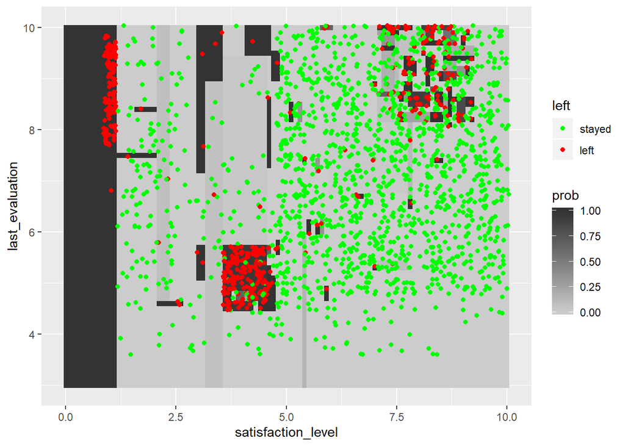

```r
# Добавляем прогноз класса и вероятность ухода
boundary_rpart2_overfit <- gr %>%
  mutate(prob = predict(m_rpart2_overfit, newdata = gr, type = "prob")[,'left'],
         class = predict(m_rpart2_overfit, newdata = gr, type = "class"))

# График разделяющей поверхности
ggplot(boundary_rpart2_overfit, aes(satisfaction_level, last_evaluation)) +
  geom_raster(aes(fill = prob)) +
  geom_jitter(aes(x = satisfaction_level,
                  y = last_evaluation,
                  colour = left),
              data = d_train) +
  scale_colour_manual(values = cmap) +
  scale_fill_gradient(low = "grey80", high = "grey20")
```

### Сравнение показателей переобученной модели на обучающей и тестовой выборках

```r
pr_rpart2_overfit_train <- predict(m_rpart2_overfit, newdata = d_train, type = "class")
pr_rpart2_overfit_test <- predict(m_rpart2_overfit, newdata = d_test, type = "class")
```

Матрица классификации и точность на обучающей выборке для переобученной модели

```r
table(predicted = pr_rpart2_overfit_train, actual = d_train$left)
```

```
##          actual
## predicted stayed left
##    stayed   1511   32
##    left       21  436
```

```r
measureACC(pr_rpart2_overfit_train, d_train$left) * 100
```

```
## [1] 97.4
```

Матрица классификации и точность на тестовой выборке для переобученной модели

```r
table(predicted = pr_rpart2_overfit_test, actual = d_test$left)
```

```
##          actual
## predicted stayed left
##    stayed    733   66
##    left       36  165
```

```r
measureACC(pr_rpart2_overfit_test, d_test$left) * 100
```

```
## [1] 89.8
```

## Упрощение дерева (pruning)

Сравнение ошибок в зависимости от параметра сложности (cp)

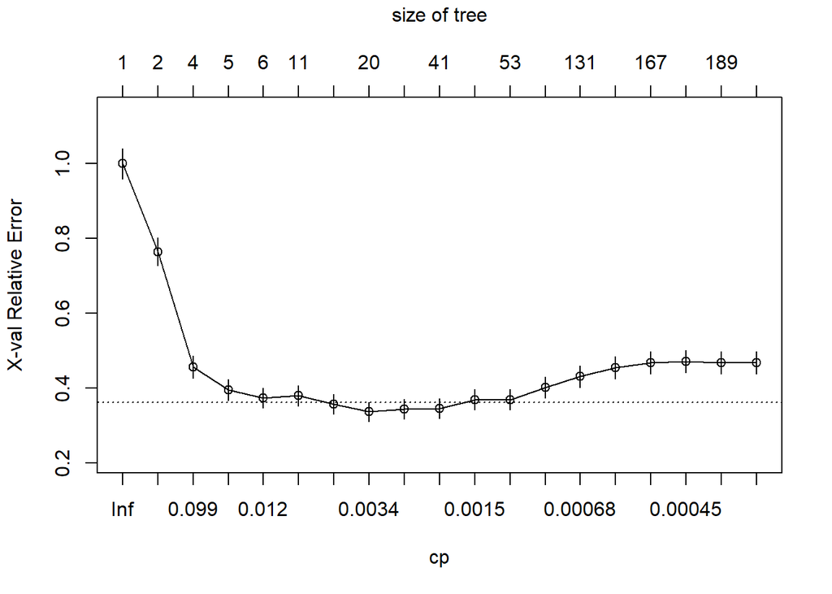

```r
plotcp(m_rpart2_overfit)
```

Упрощение дерева

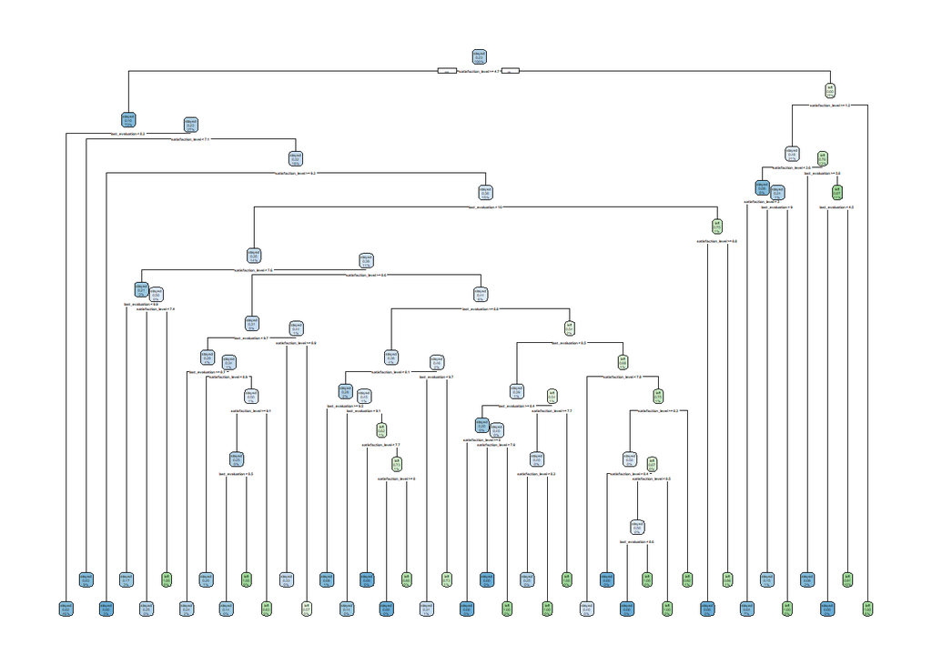

```r
m_rpart2_pruned <- prune(m_rpart2_overfit, cp = 0.002)
rpart.plot(m_rpart2_pruned)
```

### Точность модели после упрощения

```r
pr_rpart2_pruned_train <- predict(m_rpart2_pruned, newdata = d_train, type = "class")
pr_rpart2_pruned_test <- predict(m_rpart2_pruned, newdata = d_test, type = "class")
```

Матрица классификации и точность на обучающей выборке для упрощенной модели

```r
table(predicted = pr_rpart2_pruned_train, actual = d_train$left)
```

```
##          actual
## predicted stayed left
##    stayed   1500   82
##    left       32  386
```

```r
measureACC(pr_rpart2_pruned_train, d_train$left) * 100
```

```
## [1] 94.3
```

Матрица классификации и точность на тестовой выборке для упрощенной модели

```r
table(predicted = pr_rpart2_pruned_test, actual = d_test$left)
```

```
##          actual
## predicted stayed left
##    stayed    750   73
##    left       19  158
```

```r
measureACC(pr_rpart2_pruned_test, d_test$left) * 100
```

```
## [1] 90.8
```

### Визуализация разделяющей поверхности для модели после упрощения

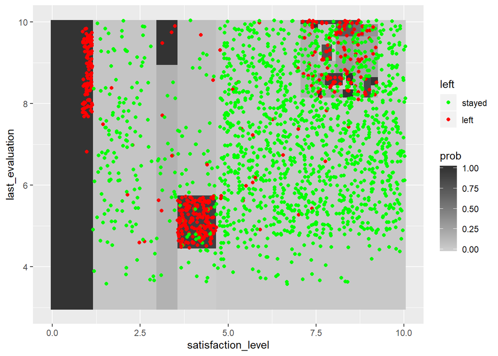

```r
# Добавляем прогноз класса и вероятность ухода
boundary_rpart2_pruned <- gr %>%
  mutate(prob = predict(m_rpart2_pruned, newdata = gr, type = "prob")[,'left'],
         class = predict(m_rpart2_pruned, newdata = gr, type = "class"))

# График разделяющей поверхности
ggplot(boundary_rpart2_pruned, aes(satisfaction_level, last_evaluation)) +
  geom_raster(aes(fill = prob)) +
  geom_jitter(aes(x = satisfaction_level,
                  y = last_evaluation,
                  colour = left),
              data = d_train) +
  scale_colour_manual(values = cmap) +
  scale_fill_gradient(low = "grey80", high = "grey20")
```

# Моделирование с использованием conditional inference tree (party)

Еще один алгоритм классификации, основанный на деревьях решений - conditional inference tree, реализованный в пакете `party`.

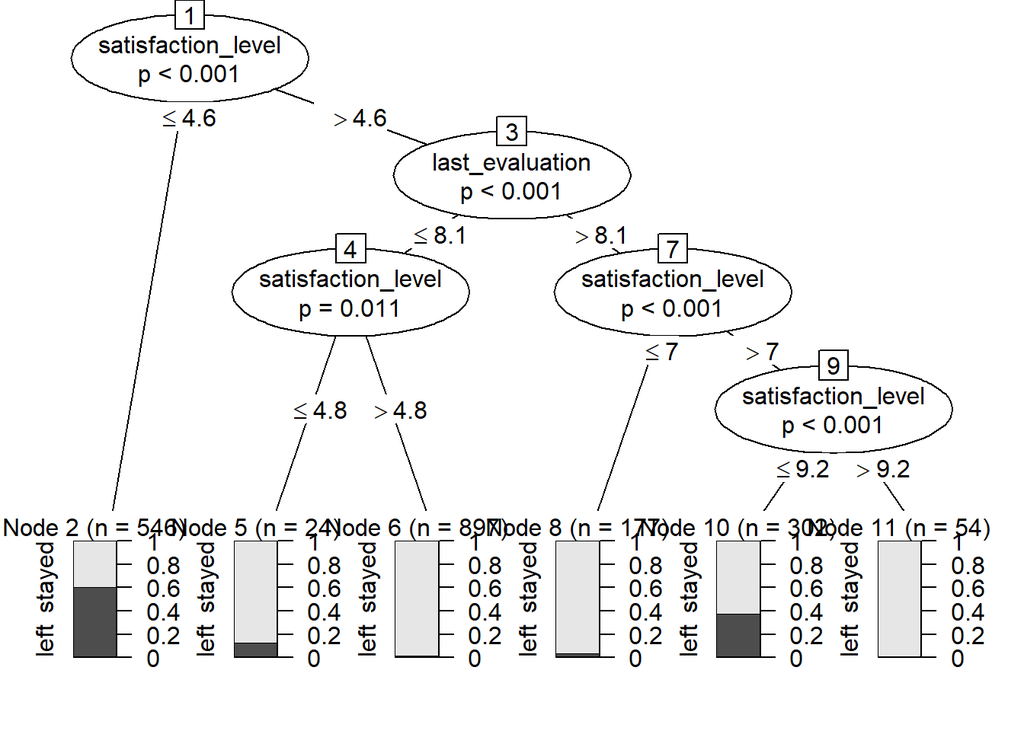

```r
m_ctree2 <- ctree(left ~ satisfaction_level + last_evaluation, data = d_train)
plot(m_ctree2)
```

## Визуализация разделяющей поверхности для модели ctree

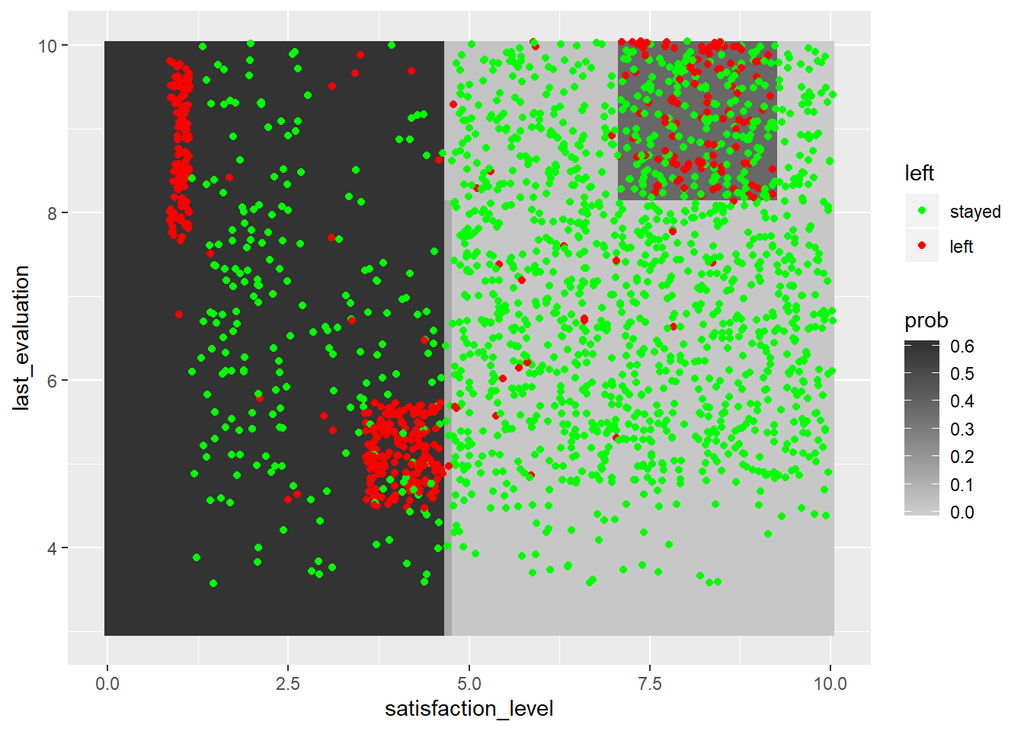

```r
# Добавляем прогноз класса и вероятность ухода
boundary_ctree2 <- gr %>%
  mutate(prob = predict(m_ctree2, newdata = gr, type = "prob")[,'left'],
         class = predict(m_ctree2, newdata = gr, type = "response"))

# График разделяющей поверхности
ggplot(boundary_ctree2, aes(satisfaction_level, last_evaluation)) +
  geom_raster(aes(fill = prob)) +
  geom_jitter(aes(x = satisfaction_level,
                  y = last_evaluation,
                  colour = left),
              data = d_train) +
  scale_colour_manual(values = cmap) +
  scale_fill_gradient(low = "grey80", high = "grey20")
```

## Точность модели ctree

```r
pr_ctree2_test <- predict(m_ctree2, newdata = d_test, type = "response")
```

Матрица классификации и точность на тестовой выборке для модели ctree

```r
table(predicted = pr_ctree2_test, actual = d_test$left)
```

```
##          actual
## predicted stayed left
##    stayed    665   85
##    left      104  146
```

```r
measureACC(pr_ctree2_test, d_test$left) * 100
```

```
## [1] 81.1
```

# Моделирование с использованием C5.0

Одним из наиболее популярных алгоритмов деревьев является C5.0 (Ross Quinlan). Этот алгоритм используется в коммерческих пакетах анализа данных и сравнительно недавно был опубликован автором под открытой лицензией и реализован в R.

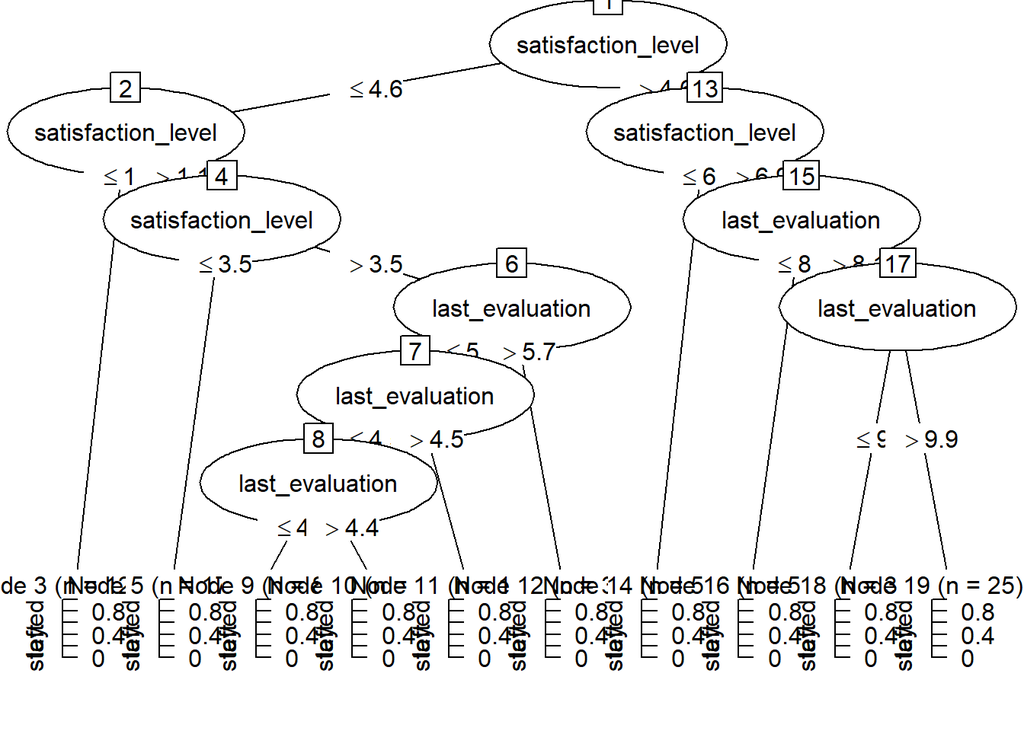

```r
m_c50 <- C5.0(left ~ satisfaction_level + last_evaluation, data = d_train)
plot(m_c50)
```

## Визуализация разделяющей поверхности для модели C5.0

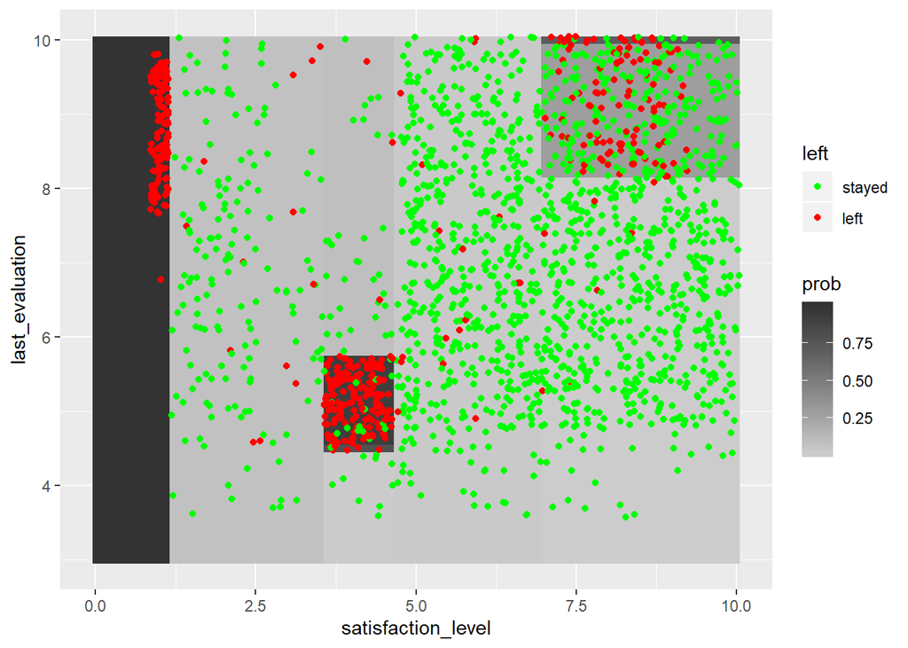

```r
# Добавляем прогноз класса и вероятность ухода
boundary_c50 <- gr %>%
  mutate(prob = predict(m_c50, newdata = gr, type = "prob")[,'left'],
         class = predict(m_c50, newdata = gr, type = "class"))

# График разделяющей поверхности
ggplot(boundary_c50, aes(satisfaction_level, last_evaluation)) +
  geom_raster(aes(fill = prob)) +
  geom_jitter(aes(x = satisfaction_level,
                  y = last_evaluation,
                  colour = left),
              data = d_train) +
  scale_colour_manual(values = cmap) +
  scale_fill_gradient(low = "grey80", high = "grey20")
```

## Точность модели C5.0

```r
pr_c50_test <- predict(m_c50, newdata = d_test, type = "class")
```

Матрица классификации и точность на тестовой выборке для модели C5.0

```r
table(predicted = pr_c50_test, actual = d_test$left)
```

```
##          actual
## predicted stayed left
##    stayed    763   77
##    left        6  154
```

```r
measureACC(pr_c50_test, d_test$left) * 100
```

```
## [1] 91.7
```

## Увеличение точности с помощью бустинга

Точность прогнозов можно повысить за счет комбинирования предсказаний нескольких моделей. В пакете C5.0 используется один из них - алгоритм адаптивного бустинга (adaptive boosting), который последовательно строит дополнительные деревья, обученные для распознавания ошибок предыдущих моделей. Затем полученный ансамбль моделей применяется для прогнозирования. Класс при прогнозировании определяется методом “голосования”.

Количество дополнительных деревьев определяется параметром `trials`, который задает максимальное их число. Алгоритм может остановиться раньше, если окажется, что дополнительные модели не улучшают точность.

```r
m_c50_boost <- C5.0(left ~ satisfaction_level + last_evaluation,
                    data = d_train, trials = 5)
m_c50_boost
```

```
##
## Call:
## C5.0.formula(formula = left ~ satisfaction_level + last_evaluation, data
##  = d_train, trials = 5)
##
## Classification Tree
## Number of samples: 2000
## Number of predictors: 2
##
## Number of boosting iterations: 5
## Average tree size: 7.6
##
## Non-standard options: attempt to group attributes
```

## Визуализация разделяющей поверхности для модели C5.0 с бустингом

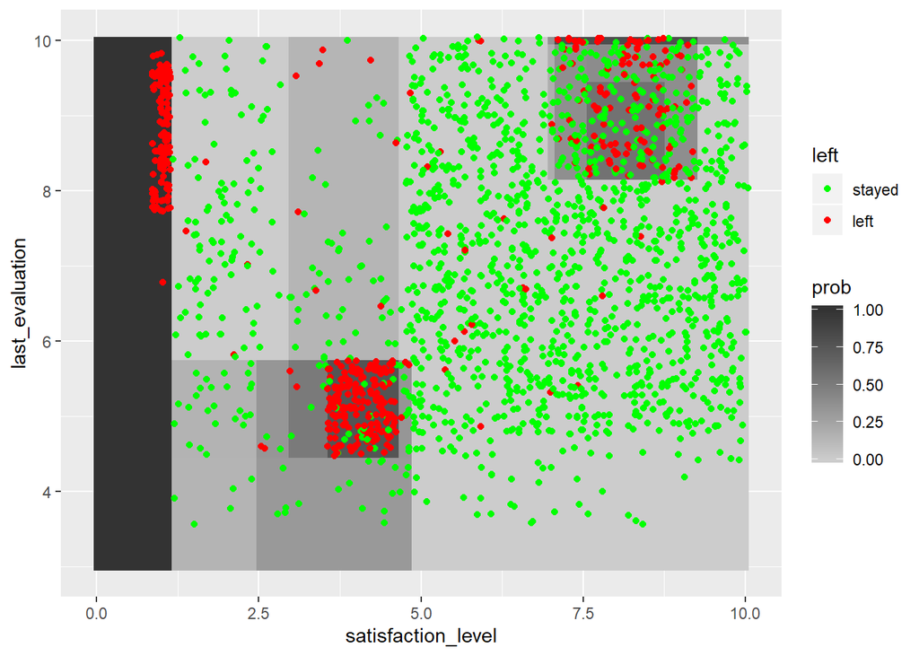

```r
# Добавляем прогноз класса и вероятность ухода
boundary_c50_boost <- gr %>%
  mutate(prob = predict(m_c50_boost, newdata = gr, type = "prob")[,'left'],
         class = predict(m_c50_boost, newdata = gr, type = "class"))

# График разделяющей поверхности
ggplot(boundary_c50_boost, aes(satisfaction_level, last_evaluation)) +
  geom_raster(aes(fill = prob)) +
  geom_jitter(aes(x = satisfaction_level,
                  y = last_evaluation,
                  colour = left),
              data = d_train) +
  scale_colour_manual(values = cmap) +
  scale_fill_gradient(low = "grey80", high = "grey20")
```

## Точность модели C5.0 с бустингом

```r
pr_c50_boost_test <- predict(m_c50_boost, newdata = d_test, type = "class")
```

Матрица классификации и точность на тестовой выборке для модели C5.0 с бустингом

```r
table(predicted = pr_c50_boost_test, actual = d_test$left)
```

```
##          actual
## predicted stayed left
##    stayed    732   48
##    left       37  183
```

```r
measureACC(pr_c50_boost_test, d_test$left) * 100
```

```
## [1] 91.5
```

В данном случае точность даже ухудшилась по сравнению с базовой моделью.

## Классификация с учетом цены ошибки

Во многих случаях ошибки классификатора не равнозначны. Например, если модель для выявления мошенничества при финансовых операциях “упустит” злонамеренную транзакцию, то цена ошибки будет намного выше, чем стоимость дополнительной проверки, если произойдет “ложная тревога”. Аналогично, при поиске клиентов, которые могут откликнуться на предложение товара или услуги - “упустить” потенциального клиента гораздо дороже, чем сделать лишний звонок. Поэтому некоторые алгоритмы построения деревьев могут учитывать различную стоимость ошибок.

Пусть, например, компании в нашем примере важнее всего выявить сколнных к уходу сотрудников, чтобы принять меры для предотвращения. Уходят часто ценные кадры, а подготовка замены им - дорогостоящее и долгое дело.

Для этого необходимо создать матрицу затрат.

```r
cost_matrix <- matrix(c(0, 5, 1, 0 ), ncol = 2, byrow = TRUE,
                      dimnames = list("predicted" = c("stayed", "left"),
                                      "actual" = c("stayed", "left")))
cost_matrix
```

```
##          actual
## predicted stayed left
##    stayed      0    5
##    left        1    0
```

Построение классификатора с учетом затрат

[figure not shown]

```r
m_c50_cost <- C5.0(left ~ satisfaction_level + last_evaluation,
                   data = d_train, cost = cost_matrix)
plot(m_c50_cost)
```

## Визуализация разделяющей поверхности для модели C5.0 с учетом затрат

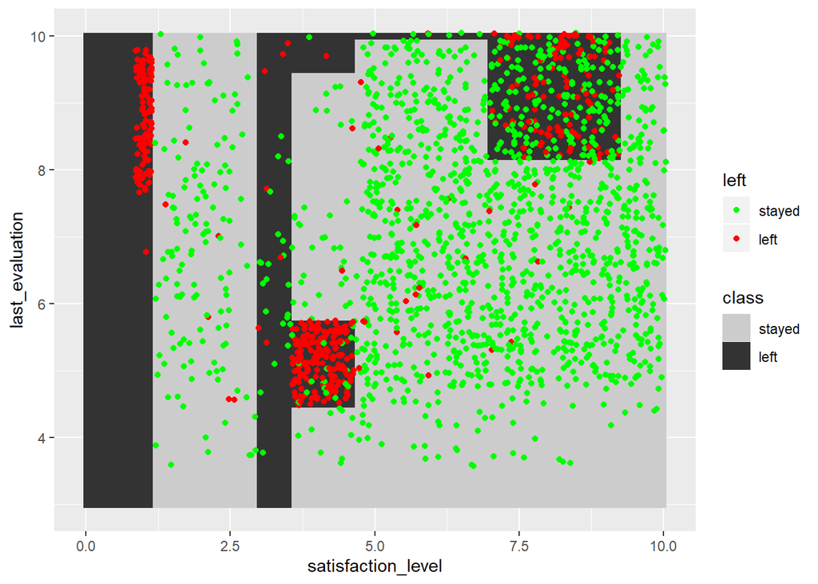

```r
# Добавляем прогноз класса и вероятность ухода
boundary_c50_cost <- gr %>%
  mutate(class = predict(m_c50_cost, newdata = gr, type = "class"))

# График разделяющей поверхности
ggplot(boundary_c50_cost, aes(satisfaction_level, last_evaluation)) +
  geom_raster(aes(fill = class)) +
  geom_jitter(aes(x = satisfaction_level,
                  y = last_evaluation,
                  colour = left),
              data = d_train) +
  scale_colour_manual(values = cmap) +
  scale_fill_manual(values = c("grey80","grey20"))
```

## Точность модели C5.0 с затратами

```r
pr_c50_cost_test <- predict(m_c50_cost, newdata = d_test, type = "class")
```

Матрица классификации и точность на тестовой выборке для модели C5.0 с затратами

```r
table(predicted = pr_c50_cost_test, actual = d_test$left)
```

```
##          actual
## predicted stayed left
##    stayed    642   14
##    left      127  217
```

```r
measureACC(pr_c50_cost_test, d_test$left) * 100
```

```
## [1] 85.9
```

# Альтернативный способ визуализации деревьев rpart

Для небольших деревьев визуализация, которую использует пакет party для деревьев ctree является более наглядной.

Деревья, которые строит rpart, также можно визуализировать этим способом. Для этого можно использовать функцию partykit::as.party()

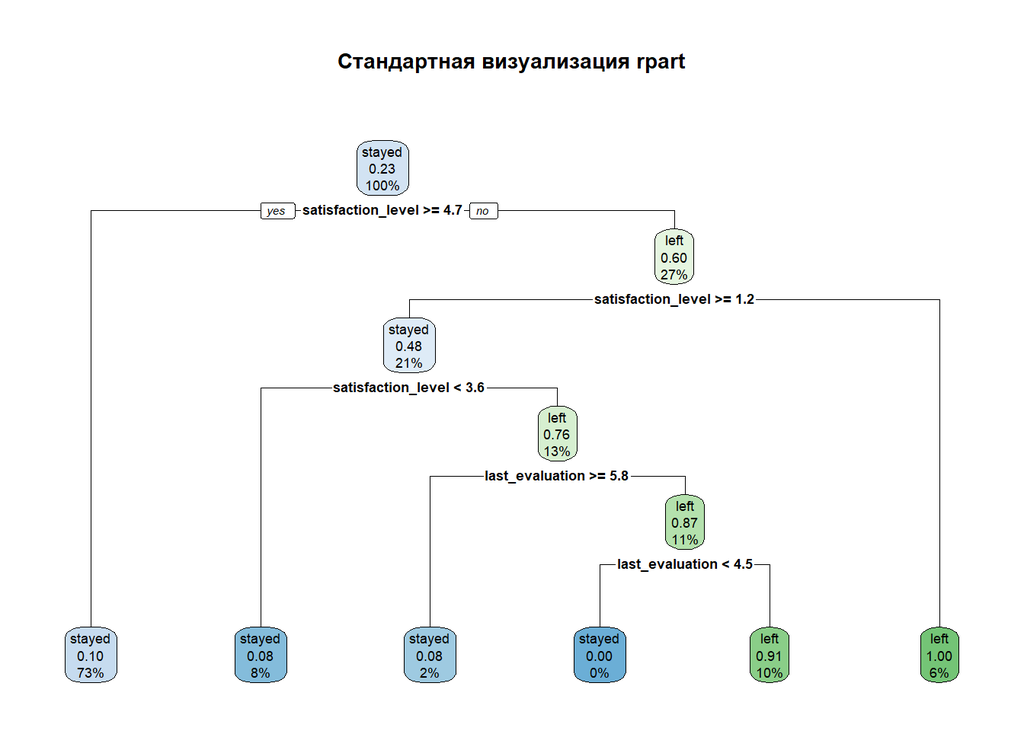

```r
rpart.plot(m_rpart2, main = "Стандартная визуализация rpart")
```

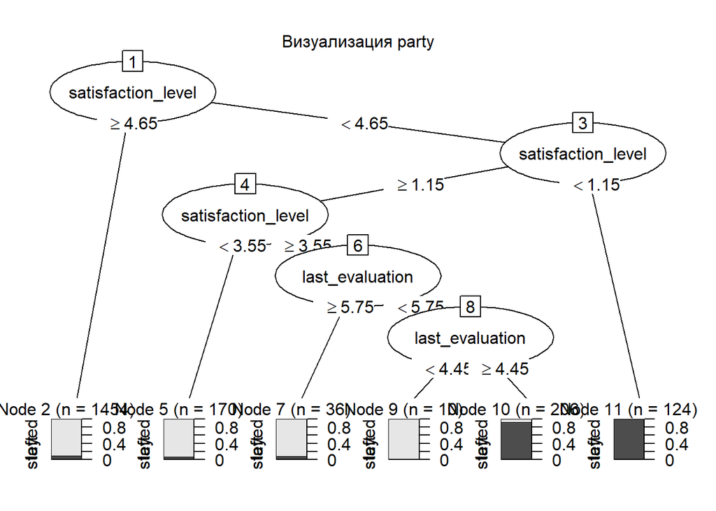

```r
plot(as.party(m_rpart2), main = "Визуализация party")
```

# Задания

1. Проведите разведочный анализ данных с целью выявления факторов, влияющих на отток сотрудников
2. Постройте на обучающей выборке модели с использованием различных методов (rpart, ctree, C5.0) с использованием всех переменных. Подтверждает ли модель ваши предположения?
3. Если вы видите, что модель не учитывает важные зависимости, выявленные визуально - попробуйте включить их принудительно. Как изменится точность модели на тестовой выборке?
4. Предположим, что компания не проводит исследование степени удовлетворенности сотрудников работой. Сколько будет “стоить” потеря этой информации с точки зрения точности моделей предсказания оттока сотрудников?